# Wstęp do analizy danych

Projekt zaliczeniowy

Anna Pietryka, Klaudia Pajor

# Wstęp

Do wykonania analizy został wykorzystany zbiór danych dotyczący wydatków gospodarstw domowych we Włoszech w roku 2013. Analiza wydatków włoskich gospodarstw domowych może być interesująca ze wzglądu na fakt, że Włochy przez wielu są kojarzone jako miejsce nieustannej zabawy i dobrej kawy. Tymczasem Włochy to jedna z największych gospodarek Europy. W ostatnich latach na północy zaczęto tworzyć wiele rozwijających się firm, co oznacza inwestycję w kulturę, edukację i zdrowie.

Tym jednak, co zostało tematem przewodnim niniejszej analizy, jest struktura wydatków na mięso i jego konkretne rodzaje. Analizie poddano również strukturę badanych rodzin.

## Przygotowanie tabeli z danymi potrzebnymi do przeprowadzenia analizy.

> **Wyjaśnienie nazw kolumn zebranych w tabeli:**
- TIPFAM - typ rodziny
- Regione - region
- NC - liczba osób w gospodarstwie domowym
- Mese - miesiąc, w którym powstał wydatek
- Eta4_1 - Wiek respondentów podany według przedziałów wiekowych:
  - 0-17
  - 18-34
  - 35-65
  - 65
- C_1201 - Cielęcina i wołowina
- C_1202 - Mięso wołowe
- C_1203 - Mięso wieprzowe
- C_1204 - Konina
- C_1205 - Mięso baranie i jagnięce
- C_1206 - Drób
- C_1207 - Króliki, indyki, dziczyzna
- C_1208 - Wędliny (kiełbasy, bekon, szynka, würstel)
- C_1209 - Przetwory i konserwy mięsne (żywność dietetyczna)

> **Fragment tabeli z danymi:**

```
##   TIPFAM NC Mese Eta4_1 C_1201 C_1202 C_1203 C_1204 C_1205 C_1206 C_1207 C_1208
## 1      1  1    7      3   0.00  22.50   0.00      0      0   0.00    0.0  13.63
## 2     10  4   11      3   0.00   0.00   0.00      0      0   0.00    0.0  13.53
## 3      7  3    7      3   0.00   0.00   0.00      0      0   0.00  135.4   0.00
## 4      4  2    9      3  16.42  13.47   9.90      0      0  21.64    0.0  42.14
## 5     10  2    3      2   0.00   0.00  34.00      0      0   0.00    0.0  37.00
## 6      7  3    6      3  25.63   0.00  13.67      0      0  11.21    0.0  16.73
##   C_1209 Regione Wszystkie_wydatki Wszystkie_wydatki_na_os
## 1   0.00       7           3229.80                3229.800
## 2   0.00       3           3566.20                 891.550
## 3   0.00       7           6069.02                2023.007
## 4   8.86      15           1726.15                 863.075
## 5   7.00      10           2013.82                1006.910
## 6   0.00      15           1143.75                 381.250
```

> **Przygotowanie oczyszczenie danych**

Na początku został sprawdzony typ zmiennych w kolumnach, żeby upewnić się, że sumowanie danych z wiersza będzie poprawną operacją:

```
## [1] "double"
```

Dane są danymi liczbowymi, więc można wykonać operację dodawania.

```r
wydatkiMieso <- tabelaDostosowana %>%
  mutate(miesoRazem = C_1201 + C_1202 + C_1203 + C_1204 + C_1205 + C_1206 + C_1207 + C_1208 + C_1209)
```

> **Fragment tabeli z danymi:**

```
##   TIPFAM NC Mese Eta4_1 C_1201 C_1202 C_1203 C_1204 C_1205 C_1206 C_1207 C_1208
## 1      1  1    7      3   0.00  22.50   0.00      0      0   0.00    0.0  13.63
## 2     10  4   11      3   0.00   0.00   0.00      0      0   0.00    0.0  13.53
## 3      7  3    7      3   0.00   0.00   0.00      0      0   0.00  135.4   0.00
## 4      4  2    9      3  16.42  13.47   9.90      0      0  21.64    0.0  42.14
## 5     10  2    3      2   0.00   0.00  34.00      0      0   0.00    0.0  37.00
## 6      7  3    6      3  25.63   0.00  13.67      0      0  11.21    0.0  16.73
##   C_1209 Regione Wszystkie_wydatki Wszystkie_wydatki_na_os miesoRazem
## 1   0.00       7           3229.80                3229.800      36.13
## 2   0.00       3           3566.20                 891.550      13.53
## 3   0.00       7           6069.02                2023.007     135.40
## 4   8.86      15           1726.15                 863.075     112.43
## 5   7.00      10           2013.82                1006.910      78.00
## 6   0.00      15           1143.75                 381.250      67.24
```

Sprawdzenie czy w danych nie występują braki:

```
##  /\     /\
## {  `---'  }
## {  O   O  }
## ==>  V <==  No need for mice. This data set is completely observed.
##  \  \|/  /
##   `-----'
```

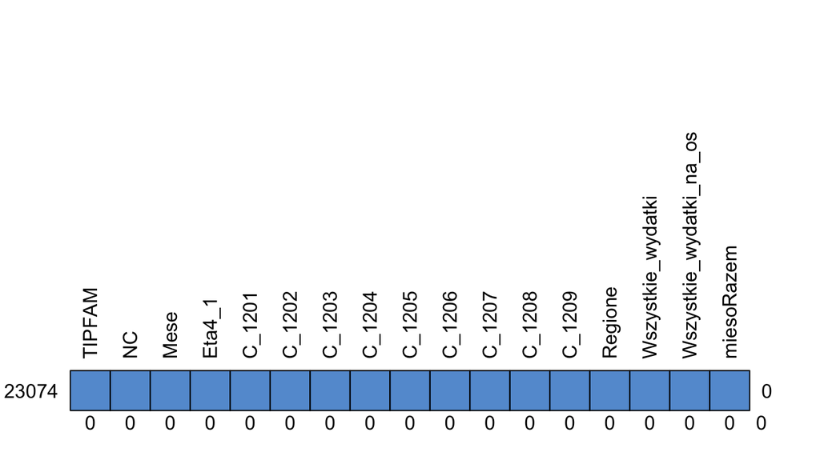

```
##       TIPFAM NC Mese Eta4_1 C_1201 C_1202 C_1203 C_1204 C_1205 C_1206 C_1207
## 23074      1  1    1      1      1      1      1      1      1      1      1
##            0  0    0      0      0      0      0      0      0      0      0
##       C_1208 C_1209 Regione Wszystkie_wydatki Wszystkie_wydatki_na_os
## 23074      1      1       1                 1                       1
##            0      0       0                 0                       0
##       miesoRazem
## 23074          1 0
##                0 0
```

W danych nie występują braki.

> **Podstawowe statystyki w kolumnach:**

```r
summary(wydatkiMieso)
```

```
##      TIPFAM             NC            Mese            Eta4_1
##  Min.   : 1.000   Min.   :1.00   Min.   : 1.000   Min.   :2.000
##  1st Qu.: 3.000   1st Qu.:1.00   1st Qu.: 3.000   1st Qu.:3.000
##  Median : 7.000   Median :2.00   Median : 6.000   Median :3.000
##  Mean   : 5.877   Mean   :2.47   Mean   : 6.425   Mean   :3.288
##  3rd Qu.: 8.000   3rd Qu.:3.00   3rd Qu.: 9.000   3rd Qu.:4.000
##  Max.   :10.000   Max.   :6.00   Max.   :12.000   Max.   :4.000
##      C_1201           C_1202           C_1203           C_1204
##  Min.   :  0.00   Min.   :  0.00   Min.   :  0.00   Min.   :  0.000
##  1st Qu.:  0.00   1st Qu.:  0.00   1st Qu.:  0.00   1st Qu.:  0.000
##  Median : 16.95   Median :  0.00   Median :  0.00   Median :  0.000
##  Mean   : 29.07   Mean   : 13.66   Mean   : 12.57   Mean   :  2.429
##  3rd Qu.: 43.94   3rd Qu.: 19.20   3rd Qu.: 18.94   3rd Qu.:  0.000
##  Max.   :347.00   Max.   :322.00   Max.   :223.80   Max.   :258.380
##      C_1205            C_1206           C_1207            C_1208
##  Min.   :  0.000   Min.   :  0.00   Min.   :  0.000   Min.   :  0.00
##  1st Qu.:  0.000   1st Qu.:  0.00   1st Qu.:  0.000   1st Qu.:  0.00
##  Median :  0.000   Median : 13.80   Median :  0.000   Median : 17.56
##  Mean   :  2.986   Mean   : 18.61   Mean   :  6.328   Mean   : 24.76
##  3rd Qu.:  0.000   3rd Qu.: 27.64   3rd Qu.:  0.000   3rd Qu.: 36.22
##  Max.   :251.920   Max.   :256.00   Max.   :188.060   Max.   :227.00
##      C_1209           Regione       Wszystkie_wydatki Wszystkie_wydatki_na_os
##  Min.   :  0.000   Min.   : 1.000   Min.   :  150.7   Min.   :   81.16
##  1st Qu.:  0.000   1st Qu.: 5.000   1st Qu.: 1408.6   1st Qu.:  640.57
##  Median :  0.000   Median : 9.000   Median : 2131.5   Median :  967.74
##  Mean   :  2.204   Mean   : 9.957   Mean   : 2581.4   Mean   : 1225.88
##  3rd Qu.:  0.000   3rd Qu.:15.000   3rd Qu.: 3174.8   3rd Qu.: 1489.75
##  Max.   :219.190   Max.   :20.000   Max.   :40433.2   Max.   :40433.24
##    miesoRazem
##  Min.   :   0.00
##  1st Qu.:  51.68
##  Median :  93.11
##  Mean   : 112.61
##  3rd Qu.: 152.06
##  Max.   :1197.91
```

*Występują duże różnice pomiędzy wartością maksymalną, minimalną oraz średnią w poszczególnych kategoriach, a także kolumnie zbiorowej. Różnice te wskazują na występowanie znacznych wartości odstających, które należy usunąć przed przystąpieniem do dalszej analizy*

> **Struktura danych przedstawiona na wykresie pudełkowym:**

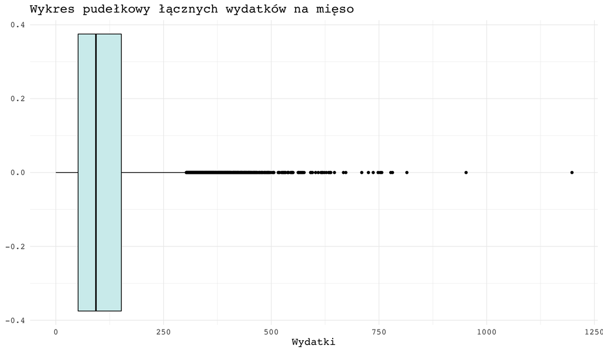

> **Struktura danych przedstawiona na histogramie:**

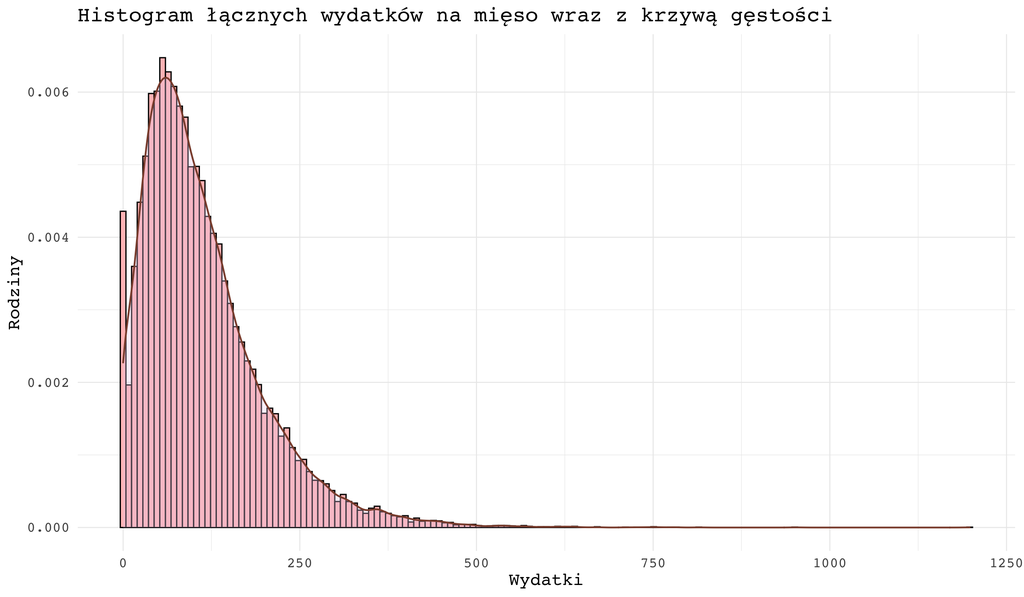

> **Zestawienie wykresów pudełkowych kolejnych kolumn zawierających wydatki na poszczególne rodzaje mięs:**

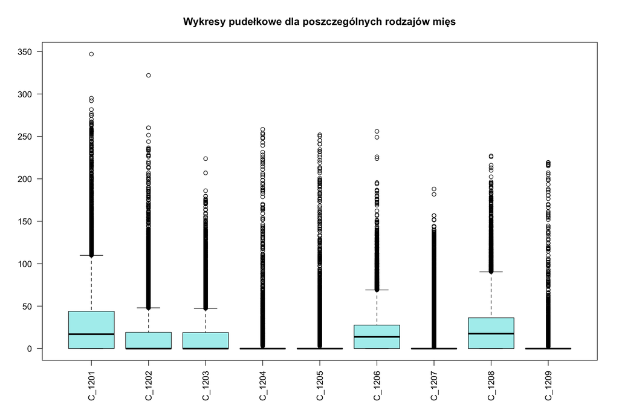

```r
boxplot(wydatkiMieso[5:13], las = 2, col = "paleturquoise2", main = "Wykresy pudełkowe dla poszczególnych rodzajów mięs")
```

Wykresy wskazują na wysoką skośność prawostronną wartości oraz występowanie wartości odstających, które należy usunąć przed dokładniejszą analizą danych. W dodatku można zauważyć spore różnice w wydatkach na poszczególne rodzaje mięs, a przy tym sporą ilość wydatków o wysokości zbliżonej lub równej zeru (pierwsza kolumna histogramu). Wartości odstające zostaną zweryfikowane w kolumnie sumującej wydatki na wszystkie rodzaje mięs, a wiersze z takimi wartościami będą usunięte i nie brane pod uwagę podczas dalszej analizy.

> **Usuwanie wartości odstających**

Tworzę tabelę pozbawioną wierszy z wartościami odstającymi na podstawie wartości w kolumnie sumującej wydatki na poszczególne rodzaje mięs:

```
##      90%      95%      99%
## 224.7900 276.4040 402.2362
```

*1% wierszy z największą wartością zsumowanych wydatków zostanie odrzucony:*

```r
wydatkiMiesoNieodstajace <- wydatkiMieso %>%
  filter(miesoRazem < 402.2362)

wydatkiMiesoNieodstajace$Mese <- factor(wydatkiMiesoNieodstajace$Mese,levels = c("1", "2", "3", "4", "5", "6", "7", "8", "9", "10", "11", "12"))
```

**Ostateczna tabela z danymi wykorzystana w dalszej analize:**

```
##   TIPFAM NC Mese Eta4_1 C_1201 C_1202 C_1203 C_1204 C_1205 C_1206 C_1207 C_1208
## 1      1  1    7      3   0.00  22.50   0.00      0      0   0.00    0.0  13.63
## 2     10  4   11      3   0.00   0.00   0.00      0      0   0.00    0.0  13.53
## 3      7  3    7      3   0.00   0.00   0.00      0      0   0.00  135.4   0.00
## 4      4  2    9      3  16.42  13.47   9.90      0      0  21.64    0.0  42.14
## 5     10  2    3      2   0.00   0.00  34.00      0      0   0.00    0.0  37.00
## 6      7  3    6      3  25.63   0.00  13.67      0      0  11.21    0.0  16.73
##   C_1209 Regione Wszystkie_wydatki Wszystkie_wydatki_na_os miesoRazem
## 1   0.00       7           3229.80                3229.800      36.13
## 2   0.00       3           3566.20                 891.550      13.53
## 3   0.00       7           6069.02                2023.007     135.40
## 4   8.86      15           1726.15                 863.075     112.43
## 5   7.00      10           2013.82                1006.910      78.00
## 6   0.00      15           1143.75                 381.250      67.24
```

# Informacje o próbie. Wstępne statystyki.

> **Typy rodzin według klasyfikacji.**

W badaniu rodziny zostały podzielone na 11 typów w zależności od tego, czy w badanym gospodarstwie domowym znajduje się osoba samotna, para bez dzieci, para z dziećmi, samotny rodzic lub inne.

Typy rodzin wymienione w nocie metolodogicznej:

- 1 = Osoba samotna w wieku poniżej 35 lat
- 2 = Osoba samotna w wieku 35-64 lat
- 3 = Osoba samotna w wieku 65 lat i starsza
- 4 = Para bez dzieci z osobą kontaktową poniżej 35 roku życia
- 5 = Para bez dzieci z osobą kontaktową w wieku 35-64 lat
- 6 = Para bez dzieci z osobą kontaktową w wieku 65 lat i starszą
- 7 = Para z 1 dzieckiem
- 8 = Para z 2 dziećmi
- 9 = Para z 3 i więcej dziećmi
- 10 = Samotny rodzic
- 11 = Inne typy

> **Tabela przedstawiająca typ rodziny i ilość tego typu rodzin biorących udział w badaniu:**

```
##   TIPFAM    n
## 1      1 3196
## 2      3 3137
## 3      4 1989
## 4      6 2802
## 5      7 3817
## 6      8 4588
## 7     10 3314
```

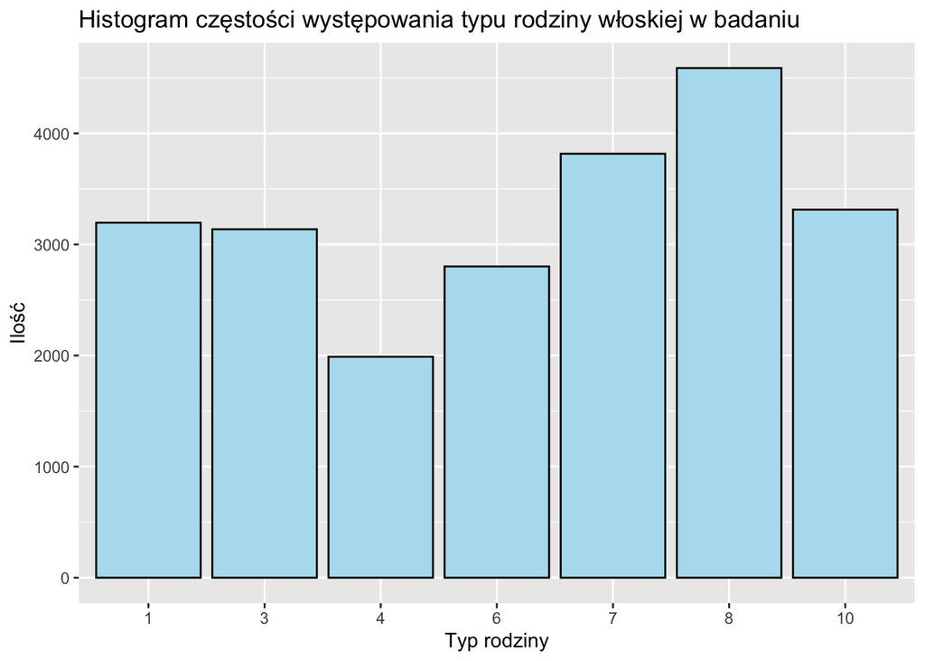

Z powyższego wykresu i tabeli wynika, że w badaniu nie wzięły udziału rodziny oznaczone według typu:

- nr 2 - Osoba samotna w wieku 35-64 lat
- nr 5 - Para bez dzieci z osobą kontaktową w wieku 35-64 lat
- nr 9 - Para z 3 i więcej dziećmi
- nr 11 - inne typy

> **Ilość członków gospodarstwa domowego w analizowanych rodzinach.**

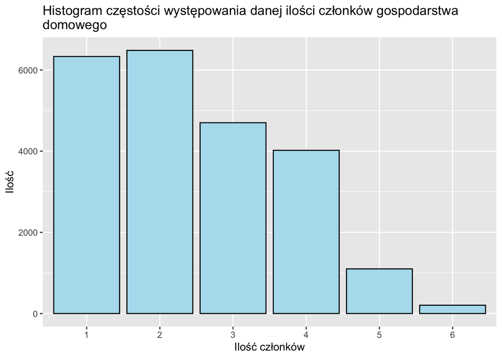

Z powyższego histogramu wynika, że w badaniu nie wzięły udziały gospodarstwa domowe, które liczą więcej niż 6 członków. Jest to informacja wymagająca dalszego zweryfikowania, ponieważ we wcześniejszej analizie wykazano, że w badaniu nie występuje typ rodziny para z trójką i więcej dzieci.  
Warto utworzyć zatem tabelę kontyngencji dla typów rodzin oraz ilości osób w domostwie.

> **Tabela kontyngencji**

```
##     y
##         1    2    3    4    5    6
##   1  3196    0    0    0    0    0
##   3  3137    0    0    0    0    0
##   4     0 1989    0    0    0    0
##   6     0 2802    0    0    0    0
##   7     0    0 3817    0    0    0
##   8     0    0    0 3639  849  100
##   10    0 1692  884  382  251  105
```

W tabeli kontyngencji dostrzec można - zdawałoby się - niezgodność: typem rodziny 8 (para z dwójką dzieci) jest 3639 domostw z czterema mieszkańcami, 849 z pięcioma i 100 z sześcioma. Najprawdopodobniej wkradł się błąd, ponieważ w nocie metodologicznej opisany jest również typ rodziny nr 9, para z trójką i więcej dzieci, który nie występuje w danych. Z drugiej strony może to być również przypadek, gdzie rodzice z dwójką dorosłych już dzieci mieszkają w jednym domu z rodzinami tychże dzieci i przez to ilość osób w domostwie zwiększa się, lecz rodzina respondenta jest mniejsza - niestety na podstawie otrzymanych danych nie jest możliwe ustalenie stanu faktycznego gospodarstw domowych w tym aspekcie, zatem są to wyłącznie przypuszczenia.

> **Ilość zbadanych gospodarstw domowych z poszczególnych regionów.**

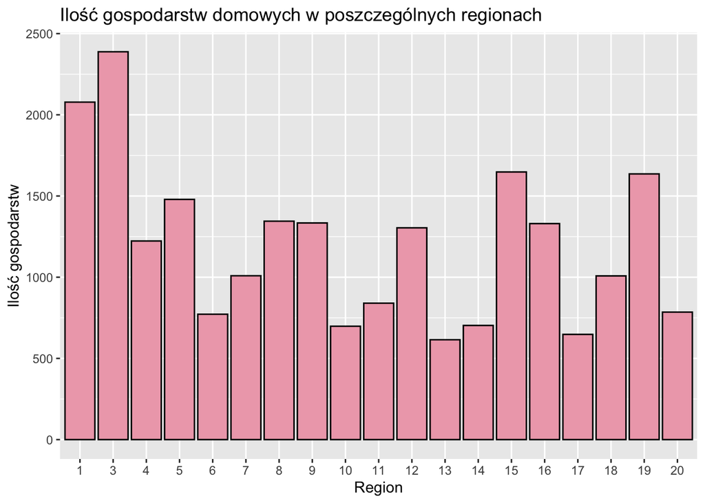

W oznaczeniach regionów włoskich nie występuje liczba 2 dlatego, że Piemont i Valle d’Aosta zostały połączone. Najwięcej gospodarstw domowych poddano badaniu w Lombardii.  
Porównując ilość badanych gospodarstw z wielkością danych regionów można stwierdzić, że w tych zajmujących większą powierzchnię poddano badaniu większą liczbę mieszkańców.

> **Ilość poddanych badaniu gospodarstw domowych w zależności od miesiąca, w którym odbywało się badanie.**

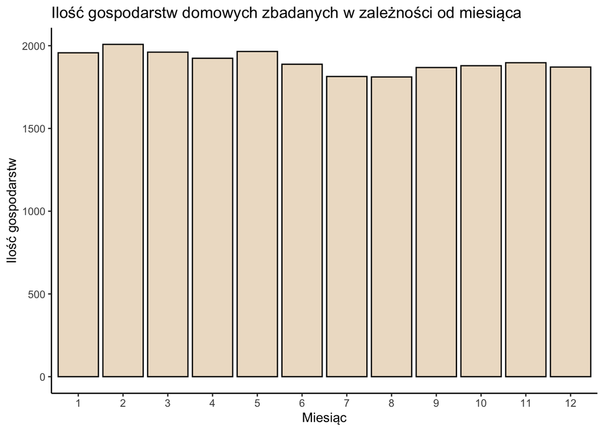

W każdym miesiącu poddano badaniu podobną ilość gospodarstw domowych.

> **Wydatki na osobę w gospodarstwach domowych.**

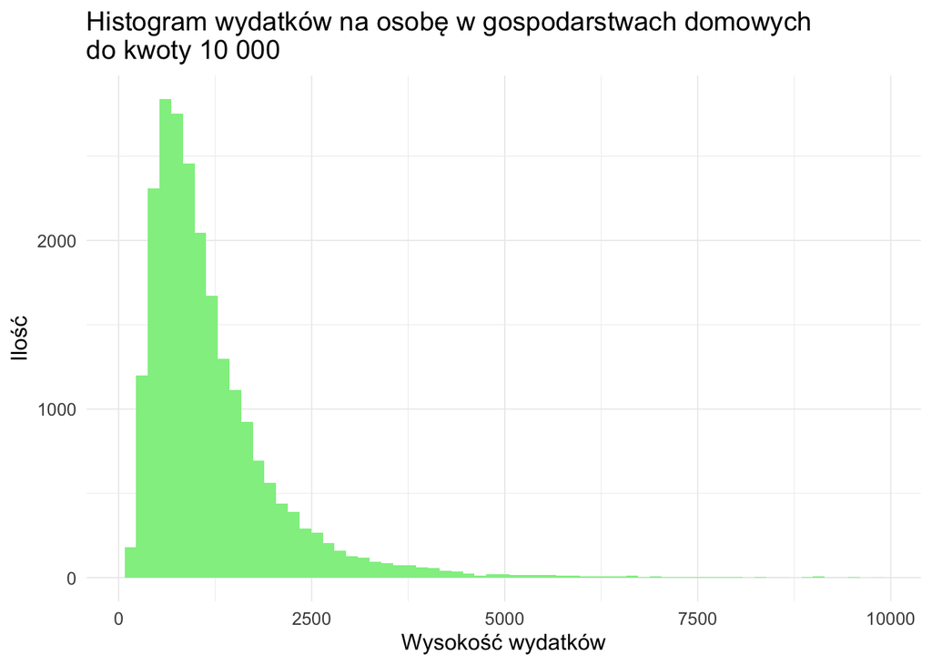

> **Średnia ilość wydatków na osobę w poszczególnych typach rodzin.**

```
## # A tibble: 7 x 2
##   TIPFAM srednia
##    <dbl>   <dbl>
## 1      1   2076.
## 2      3   1464.
## 3      4   1434.
## 4      6   1127.
## 5      7   1007.
## 6      8    792.
## 7     10    952.
```

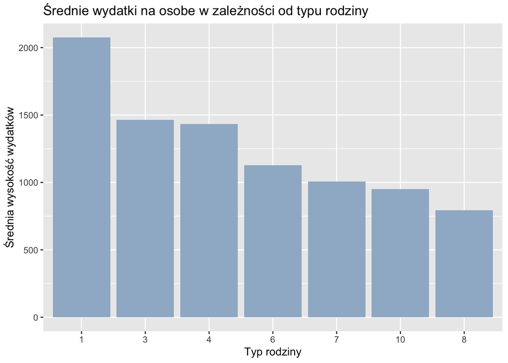

Największe średnie wydatki na osobę występują w gospodarstwie domowym, w którym znajduję się jedna osoba samotna w wieku poniżej 35 lat. Jest to stosunkowo zrozumiałe, ponieważ taka osoba sama pokrywa opłaty związane z mieszkaniem, rachunkami i utrzymaniem. Znacznie mniej wydają osoby starsze, powyżej 65 roku życia, mieszkające samotnie. Ta różnica może wynikać z tego, że osoby do 35 roku życia zazwyczaj rozwijają swoją karierę zawodową, zarabiają więcej, a także prowadzą bardziej towarzyski tryb życia. Natomiast osoby starsze wolą oszczędzać i nie udzielają się towarzysko równie bardzo jak młodsze - przez to ich średnie wydatki są znacznie niższe.

Średnio najmniej wydają gospodarstwa domowe składające się z pary z dwójką dzieci. Może to być spowodowane nieścisłością w danych, która została opisana wcześniej.

> **Średnia ilość wydatków w poszczególnych regionach Włoch.**

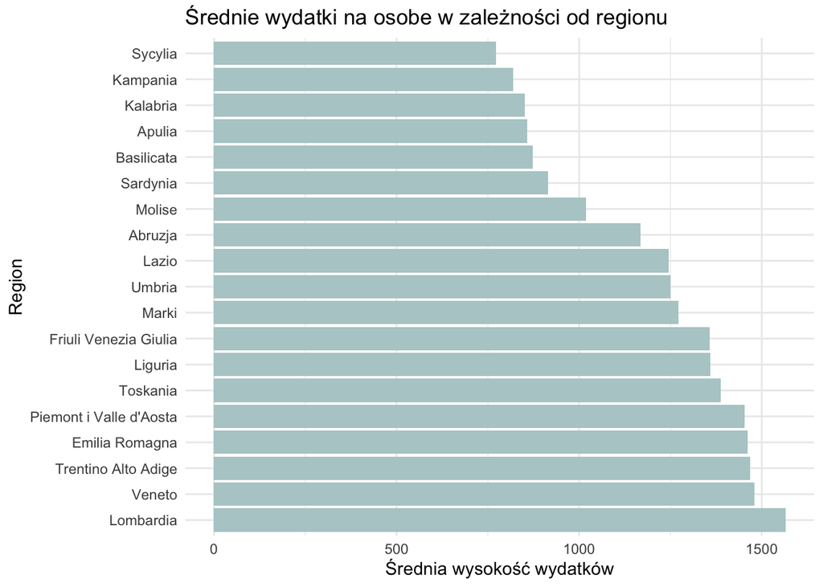

```
## # A tibble: 19 x 2
##    Regione                 srednia
##    <chr>                     <dbl>
##  1 Sycylia                    773.
##  2 Kampania                   820.
##  3 Kalabria                   851.
##  4 Apulia                     857.
##  5 Basilicata                 872.
##  6 Sardynia                   915.
##  7 Molise                    1019.
##  8 Abruzja                   1168.
##  9 Lazio                     1245.
## 10 Umbria                    1250.
## 11 Marki                     1272.
## 12 Friuli Venezia Giulia     1357.
## 13 Liguria                   1360.
## 14 Toskania                  1388.
## 15 Piemont i Valle d'Aosta   1453.
## 16 Emilia Romagna            1462.
## 17 Trentino Alto Adige       1468.
## 18 Veneto                    1481.
## 19 Lombardia                 1565.
```

W regionach należących do północnej części Włoch średnie wydatki na osobę są wyższe niż na południu. Najmniej wydaje się na Sycylii, co potwierdza fakt, że w tych rejonach bardzo ciężko założyć własną działalność gospodarczą lub znaleźć dobrze płatną pracę. Dlatego dużo młodych osób wyjeżdża na północ Włoch w poszukiwaniu lepszych perspektyw.

# Statystyki dotyczące struktury wydatków na mięsa:

> **Struktura wydatków na mięso w zależności od miesiąca i ilości członków gospodarstwa domowego**

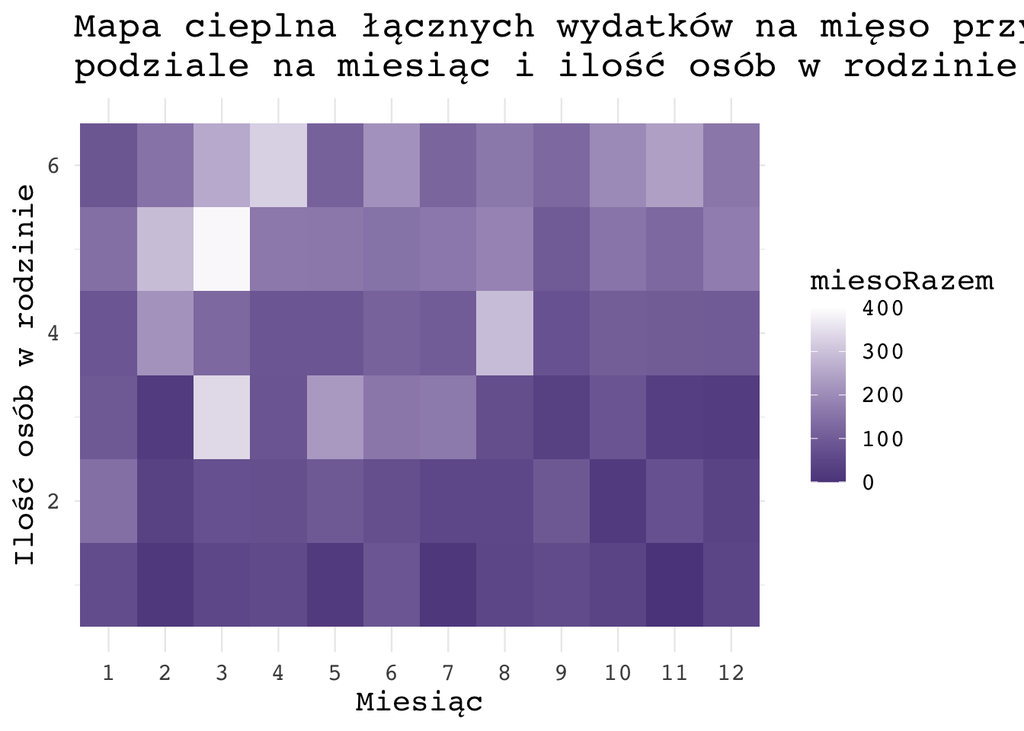

Patrząc na mapę cieplną można zauważyć, że najwyższe wydatki na mięso występują w marcu przy liczbie osób równej 3 i 5, a te najniższe - zobrazowane przez najciemniejszy kolor - w lutym dla ilości osób mniejszej niż 4, maju, lipcu i listopadzie dla jednej osoby w rodzinie, w październiku dla dwóch osób. Całość wykresu potwierdza intuicję, że wraz ze zwiększaniem się ilości osób w rodzinie, wydatki na mięso również wzrastają. W dalszej części analizy zostanie to zweryfikowane dodatkowo za pomocą regresji.

> **Wydatki na mięso w zależności od miesiąca**

```
##    Mese        n
## 1     4 217607.0
## 2     2 216500.6
## 3     1 215931.1
## 4     3 215341.7
## 5     5 210581.6
## 6     9 208482.2
## 7    12 207620.2
## 8    10 202018.5
## 9     6 201097.6
## 10    8 198288.6
## 11   11 196728.6
## 12    7 195353.4
```

Największe wydatki na mięso u rodzin Włoskich występują w kwietniu, później w lutym i styczniu.

> **Wydatki na mięso w zależności od typu rodziny:**

```
## # A tibble: 7 x 2
##   TIPFAM sredniWydatek
##    <dbl>         <dbl>
## 1      1          71.0
## 2      3          71.4
## 3      4         103.
## 4      6         109.
## 5      7         126.
## 6      8         142.
## 7     10         118.
```

Najwięcej wydaje typ rodziny nr 8 (Coppia con 2 figli = Para z 2 dzieci), najmniej typ nr 1 (Persona sola con meno di 35 anni = Osoba samotna w wieku poniżej 35 lat). Można to również zaobserwować na wykresie poniżej.

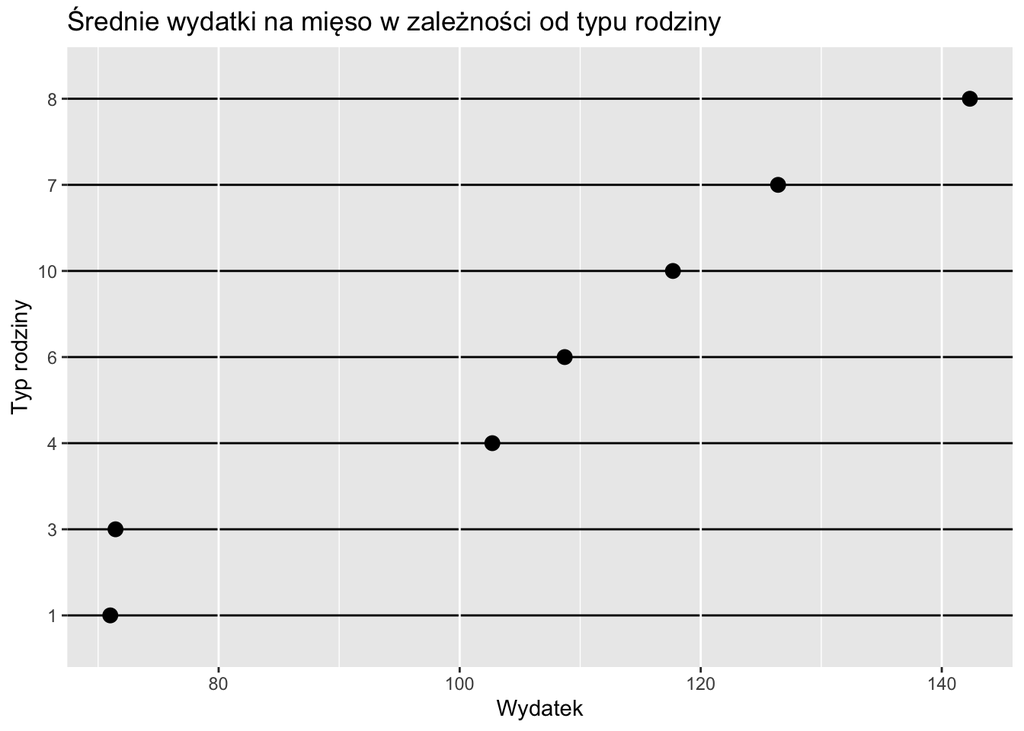

# Hipotezy

## Hipoteza pierwsza

> *Największy udział w wydatkach w ciągu roku na mięso u rodzin włoskich stanowią wydatki na wędliny*

```r
sumyWydatkow <- colSums(wydatkiMiesoNieodstajace[(5:13)])
sumyWydatkow
```

```
##    C_1201    C_1202    C_1203    C_1204    C_1205    C_1206    C_1207    C_1208
## 638353.48 300393.90 277248.36  53120.94  63264.62 413712.88 138590.86 552730.95
##    C_1209
##  48135.01
```

Zgodnie z wynikami największy udział w wydatkach w ciągu roku na mięso stanowią wydatki na cielęcinę i wołowinę (C_1201). Dopiero następnymi największymi są wydatki na wędliny (C_1208).

Odrzucam zatem hipotezę pierwszą, wędliny nie stanowią największego udziału w wydatkach na mięso w ciągu roku u rodzin włoskich.

## Hipoteza druga

> *Wędliny dla grupy dochodowej para z dzieckiem są dobrem wyższego rzędu.*

Aby zaklasyfikować dobra do właściwego typu, należy podzielić gospodarstwa domowe na grupy dochodowe. Przed podziałem zostanie zweryfikowany rozkład wydatków całkowitych.

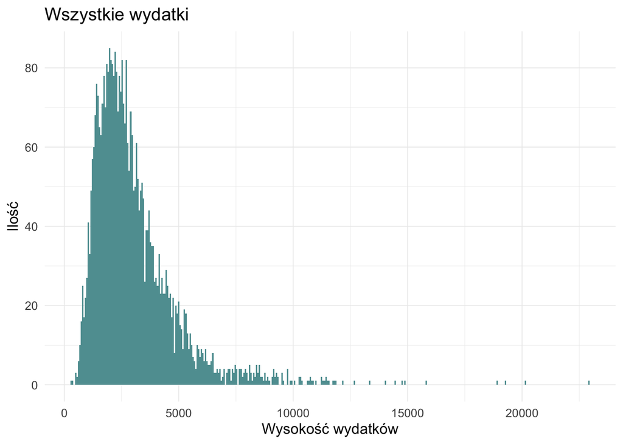

Na wykresie powyżej można zauważyć, że w wydatkach ogółem występuje dużo wartości odstających, dlatego 1 % największy wartości zostanie usunięty.

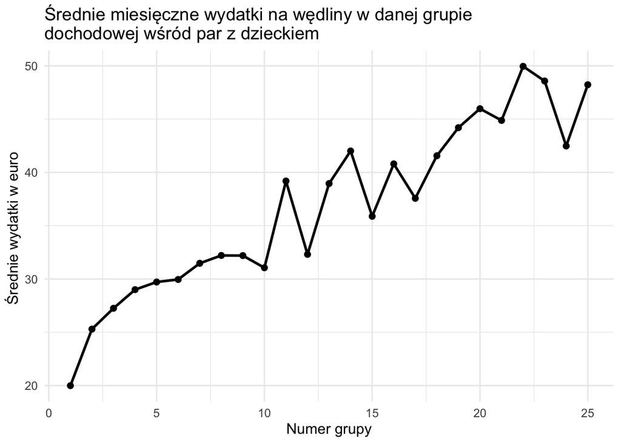

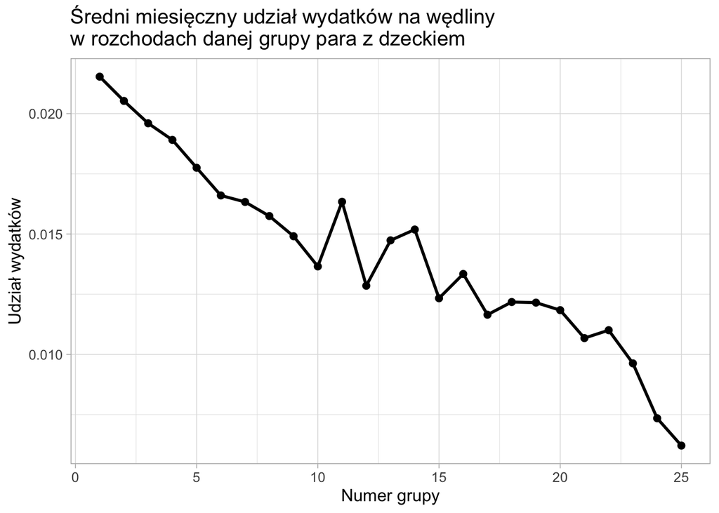

Wyżej wskazane wykresy wskazują, że wydatki na wędliny dla grupy dochodowej para z dzieckiem są dobrem wyższego rzędu. W następnym kroku zostanie dopasowana funkcja.

```r
#REGRESJA
#X - sredni calkowity dochod w gospodarstwie w kwantylach
#Y - sredni wydatk na wedliny w kwantylach
#C - sredni poziom dochodu przy ktorym pojawia sie wydatek

m <- nls(sredni_wydatkek_w_gr_dochodowej ~ (a * (srednie_dochod_w_gr - c))/(srednie_dochod_w_gr + b), data = dane_model_koncowy, start = list(a=max(dane_model_koncowy$sredni_wydatkek_w_gr_dochodowej),b=100, c = 934))

coef(m)
```

```
##          a          b          c
##   60.26333 1250.09145  226.44171
```

```r
summary(m)
```

```
##
## Formula: sredni_wydatkek_w_gr_dochodowej ~ (a * (srednie_dochod_w_gr -
##     c))/(srednie_dochod_w_gr + b)
##
## Parameters:
##    Estimate Std. Error t value Pr(>|t|)
## a   60.2633     0.4192  143.78   <2e-16 ***
## b 1250.0915    62.4406   20.02   <2e-16 ***
## c  226.4417    21.6046   10.48   <2e-16 ***
## ---
## Signif. codes:  0 '***' 0.001 '**' 0.01 '*' 0.05 '.' 0.1 ' ' 1
##
## Residual standard error: 2.596 on 2953 degrees of freedom
##
## Number of iterations to convergence: 7
## Achieved convergence tolerance: 5.941e-06
```

Wszystkie oszacowania parametrów są dodatnie i statystycznie istotne.

Wykres dopasowania funkcji Tornquista II rodzaju dla wędlin.

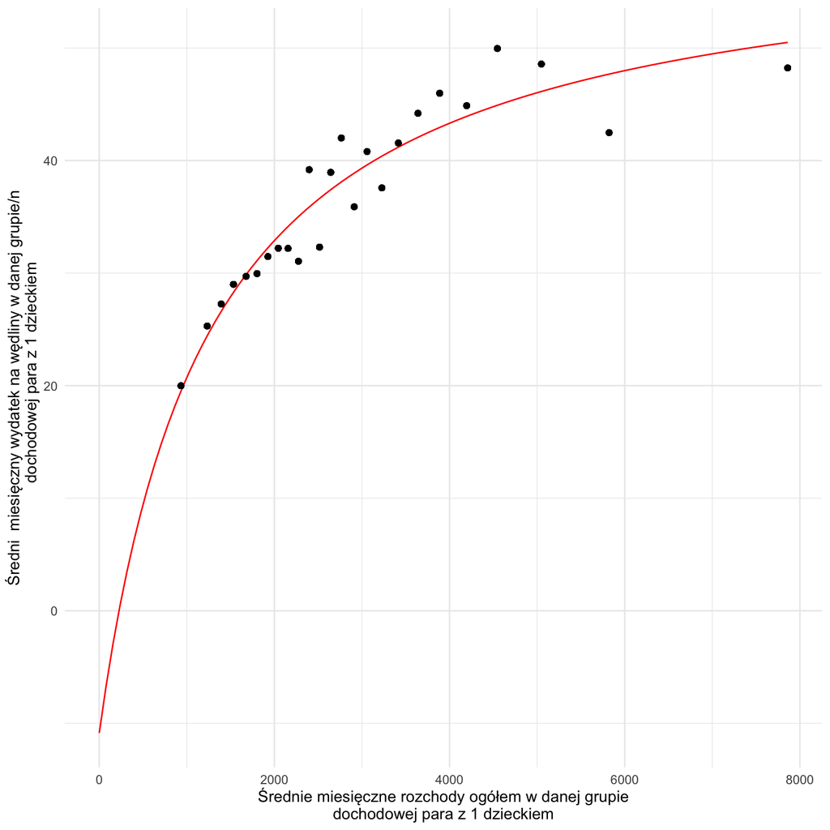

## Hipoteza trzecia

> *Wydatki na cielęcinę i wołowinę są bardziej zróżnicowanie wielkościowo pomiędzy rodzinami niż wydatki na wędliny*

```r
leveneTest(wydatek ~ rodzajMiesa, data = doLevene)
```

```
## Levene's Test for Homogeneity of Variance (center = median)
##          Df F value    Pr(>F)
## group     1  934.71 < 2.2e-16 ***
##       45684
## ---
## Signif. codes:  0 '***' 0.001 '**' 0.01 '*' 0.05 '.' 0.1 ' ' 1
```

p-value < 0.05, zatem odrzucam hipotezę zerową testu Levene mówiącą o braku istotnych różnic w wariancji pomiędzy grupami na rzecz hipotezy alternatywnej - pomiędzy grupami występują istotne różnice w wariancji.

```r
var(wydatkiMiesoNieodstajace$C_1201)
```

```
## [1] 1361.305
```

```r
var(wydatkiMiesoNieodstajace$C_1208)
```

```
## [1] 711.0871
```

Zgodnie z przewidywaniami, większa wariancja występuje w przypadku wydatków na cielęcinę i wołowinę niż wędliny. Przyjmuję zatem hipotezę trzecią. Wynik można zweryfikować też na wykresie poniżej.

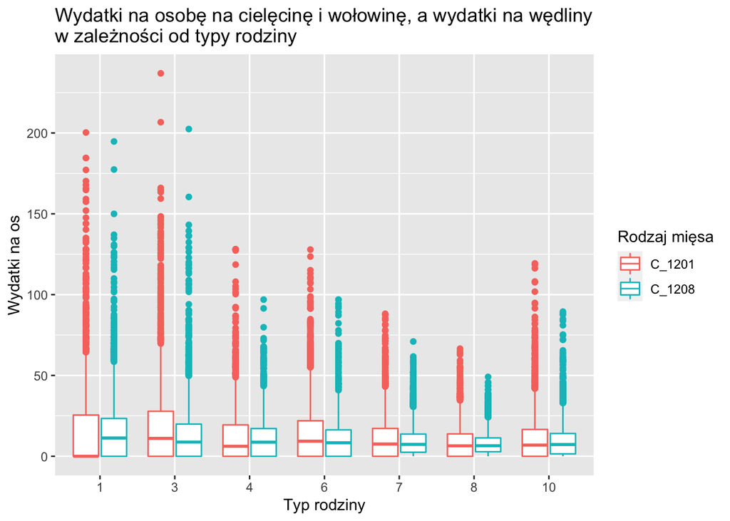

## Hioteza czwarta

> *Wysokość wydatków na mięso ogółem zależy od miesiąca*

Przyjmuję poziom istotności 5%.

By móc przeprowadzić test ANOVA, spełnione muszą być założenia:

1. Homogeniczność wariancji
2. Skala ilościowa zmiennej zależnej (spełnione)
3. Rozkład normalny podgrup
4. Niezależność obserwacji (spełnione)

```r
typeof(wydatkiMiesoNieodstajace$Mese)
```

```
## [1] "integer"
```

```r
wydatkiMiesoNieodstajace$Mese <- as.character(wydatkiMiesoNieodstajace$Mese)
```

Weryfikacja założeń ANOVY:

```r
# Jednorodność (homogeniczność) wariancji w podgrupach
leveneTest(miesoRazem ~ Mese, data = wydatkiMiesoNieodstajace)
```

```
## Levene's Test for Homogeneity of Variance (center = median)
##          Df F value   Pr(>F)
## group    11  2.3407 0.007098 **
##       22831
## ---
## Signif. codes:  0 '***' 0.001 '**' 0.01 '*' 0.05 '.' 0.1 ' ' 1
```

Przyjmując poziom istotności 0.05 odrzucam hipotezę zerową testu Levene mówiącą o braku różnic w wariancji pomiędzy grupami na rzecz hipotezy alternatywnej - pomiędzy grupami występują istotne różnice w wariancji.

W przypadku niespełnienia jednego z założeń ANOVY wykonuję jej odpowiednik - nieparametryczny test Kruskala-Wallisa:

```r
kruskal.test(miesoRazem ~ Mese, data = wydatkiMiesoNieodstajace)
```

```
##
##  Kruskal-Wallis rank sum test
##
## data:  miesoRazem by Mese
## Kruskal-Wallis chi-squared = 18.531, df = 11, p-value = 0.07004
```

Dla p-value > 0.05 nie ma podstaw do odrzucenia hipotezy zerowej testu Kruskala-Wallisa mówiącą o braku istotnych różnic pomiędzy grupami. Oznacza to, że wysokość wydatków na mięso ogółem nie zależy istotnie od miesiąca przy poziomie istotności 5%. Wyniki ANOVY potwierdzić można wykresem:

> **Mapa cieplna wydatków na poszczególne rodzaje mięsa zależna od miesiąca:**

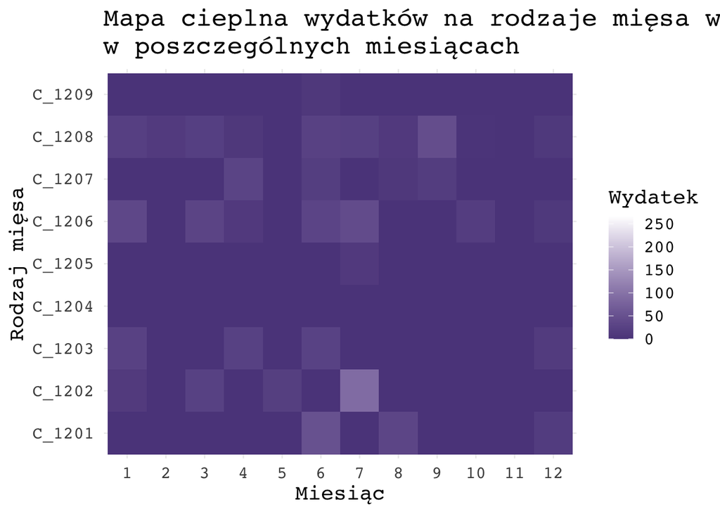

Według powyższego wykresu zauważyć można, że struktura wydatków na różne rodzaje mięs zmienia się w poszczególnych miesiącach bardzo nieznacznie, a w przypadku C_1204, C_1205 i C_1209 jest niemal (lub całkowicie) niewidoczna.

# Hipoteza piąta

> *Wysokość całkowitych wydatków na mięso zależy od typu rodziny*

```r
kruskal.test(miesoRazem ~ TIPFAM, data = wydatkiMiesoNieodstajace)
```

```
##
##  Kruskal-Wallis rank sum test
##
## data:  miesoRazem by TIPFAM
## Kruskal-Wallis chi-squared = 3054.1, df = 6, p-value < 2.2e-16
```

Dla p-value < 0.05 odrzucam hipotezę zerową testu Kruskala-Wallisa mówiącą o braku istotnych różnic pomiędzy grupami. Oznacza to, że wysokość wydatków na mięso ogółem zależy istotnie od typu rodziny przy poziomie istotności 5%. Test post-hoc Dunna:

```r
dunn.test(wydatkiMiesoNieodstajace$miesoRazem, wydatkiMiesoNieodstajace$TIPFAM, method="bonferroni")
```

```
##   Kruskal-Wallis rank sum test
##
## data: x and group
## Kruskal-Wallis chi-squared = 3054.0595, df = 6, p-value = 0
##
##
##                            Comparison of x by group
##                                  (Bonferroni)
## Col Mean-|
## Row Mean |          1         10          3          4          6          7
## ---------+------------------------------------------------------------------
##       10 |  -26.38016
##          |    0.0000*
##        3 |   0.027701   26.28272
##          |     1.0000    0.0000*
##        4 |  -16.34717   6.598002  -16.31280
##          |    0.0000*    0.0000*    0.0000*
##        6 |  -21.69373   3.607400  -21.62583  -3.225306
##          |    0.0000*    0.0032*    0.0000*    0.0132*
##        7 |  -32.90399  -5.682056  -32.76575  -11.64583  -9.144524
##          |    0.0000*    0.0000*    0.0000*    0.0000*    0.0000*
##        8 |  -42.81175  -14.57970  -42.60646  -19.35167  -17.72422  -9.013550
##          |    0.0000*    0.0000*    0.0000*    0.0000*    0.0000*    0.0000*
##
## alpha = 0.05
## Reject Ho if p <= alpha/2
```

- nr 1: Persona sola con meno di 35 anni = Osoba samotna w wieku poniżej 35 lat
- nr 3: Persona sola con 65 anni e più = Osoba samotna, która ukończyła 65 lat

# Regresja logistyczna

> *Czy to, że rodzina przekracza średnią miesięczną wysokość wydatków na mięso, ma istotny związek z typem rodziny, wiekiem osoby kontaktowej lub kwartałami, w których dokonywane były zakupy?*

```r
doLogistycznej <- wydatkiMiesoNieodstajace

# tworzę kolumnę z kwartałami
doLogistycznej$Kwartal <- ifelse(doLogistycznej$Mese == "1" | doLogistycznej$Mese == "2" | doLogistycznej$Mese == "3", "pierwszy", ifelse(doLogistycznej$Mese == "4" | doLogistycznej$Mese == "5" | doLogistycznej$Mese == "6", "drugi", ifelse(doLogistycznej$Mese == "7" | doLogistycznej$Mese == "8" | doLogistycznej$Mese == "9", "trzeci", ifelse(doLogistycznej$Mese == "10" | doLogistycznej$Mese == "11" | doLogistycznej$Mese == "12", "czwarty", doLogistycznej$Mese))))

doLogistycznej$Kwartal <- factor(doLogistycznej$Kwartal,levels = c("pierwszy", "drugi", "trzeci", "czwarty"))

srednia <- mean(wydatkiMiesoNieodstajace$miesoRazem)
doLogistycznej$doMiesaRazem <- ifelse(doLogistycznej$miesoRazem>=srednia, 1, 0) # jeśli wydali więcej niż wynosi średnia lub równo średniej, zastępuję numerem 1, w przeciwnym wypadku 0
```

```r
wynikLogist1 <- glm(formula = doMiesaRazem ~ as.factor(TIPFAM) + Kwartal + as.factor(Eta4_1), data = doLogistycznej, family = binomial)
summary(wynikLogist1)
```

```
##
## Call:
## glm(formula = doMiesaRazem ~ as.factor(TIPFAM) + Kwartal + as.factor(Eta4_1),
##     family = binomial, data = doLogistycznej)
##
## Deviance Residuals:
##     Min       1Q   Median       3Q      Max
## -1.4103  -1.0304  -0.6666   1.1439   1.8879
##
## Coefficients:
##                     Estimate Std. Error z value Pr(>|z|)
## (Intercept)         -1.53178    0.06889 -22.234  < 2e-16 ***
## as.factor(TIPFAM)3  -0.09289    0.07962  -1.167  0.24336
## as.factor(TIPFAM)4   0.86692    0.06339  13.676  < 2e-16 ***
## as.factor(TIPFAM)6   0.94211    0.07616  12.369  < 2e-16 ***
## as.factor(TIPFAM)7   1.37575    0.05543  24.822  < 2e-16 ***
## as.factor(TIPFAM)8   1.75758    0.05360  32.793  < 2e-16 ***
## as.factor(TIPFAM)10  1.14485    0.05888  19.444  < 2e-16 ***
## Kwartaldrugi        -0.03018    0.03935  -0.767  0.44317
## Kwartaltrzeci        0.04105    0.03982   1.031  0.30254
## Kwartalczwarty      -0.06609    0.03969  -1.665  0.09590 .
## as.factor(Eta4_1)3   0.26569    0.05772   4.603 4.16e-06 ***
## as.factor(Eta4_1)4   0.23365    0.07166   3.260  0.00111 **
## ---
## Signif. codes:  0 '***' 0.001 '**' 0.01 '*' 0.05 '.' 0.1 ' ' 1
##
## (Dispersion parameter for binomial family taken to be 1)
##
##     Null deviance: 31027  on 22842  degrees of freedom
## Residual deviance: 28792  on 22831  degrees of freedom
## AIC: 28816
##
## Number of Fisher Scoring iterations: 4
```

Klasy referencyjne to: dla typu rodziny nr 1, osoba samotna w wieku poniżej 35 lat, dla kwartałów kwartał pierwszy, a dla wieku respondentów przedział wiekowy oznaczony numerem 2, czyli od 18 do 34 lat.

Typ rodziny TIPFAM *przypomnienie*:

- nr 1: Osoba samotna w wieku poniżej 35 lat
- nr 3: Osoba samotna, która ukończyła 65 lat
- nr 4: Bezdzietna para, gdzie respondent to osoba poniżej 35 roku życia
- nr 6: Bezdzietna para, gdzie respondent to osoba powyżej 65 roku życia
- nr 7: Para z 1 dzieckiem
- nr 8: Para z 2 dzieci
- nr 10: Samotny rodzic

Zgodnie z wynikami powyższej regresji, można wysunąć następujące wnioski:

*obliczenia dla wzoru*

$$S = \frac1{e^{Estimate}}$$

```
## [1] 1.211113
```

```
## [1] 0.4177216
```

Bezdzietna para, gdzie respondent to osoba poniżej 35 roku życia, wydaje więcej na mięso niż osoba samotna w tym samym przedziale wiekowym. Szansa przekroczenia średniej wydatków u osób samotnych poniżej 35 roku życia stanowi około 41,8% szansy takiej pary.

```
## [1] 0.4302194
```

```
## [1] 0.2557871
```

Pary z jednym dzieckiem wydają na mięso jeszcze więcej niż poprzednie analizowane grupy. Szansa przekroczenia średniej wydatków osób samotnych stanowi 25,6% szans takiej pary.

```
## [1] 0.1698873
```

Wydającym na mięso najwięcej spośród pozostałych typów rodzin jest typ nr 8, para z dwójką dzieci. Szanse przekroczenia średniej wydatków u osoby samotnej poniżej 35 roku życia stanowi zaledwie niecałe 17% szansy pary z dwójką dzieci (8,6 punktów procentowych mniej niż u par z jednym dzieckiem).

```
## [1] 0.3273059
```

Szanse na przekroczenie średniej wydatków samotnego rodzica plasuje się pomiędzy szansami par bezdzietnych a par z jednym dzieckiem. Takie szanse u osób samotnych to 32,7% szans samotnych rodziców. Uzyskujemy zatem informację, że szanse na przekroczenie średniej wydatków u samotnych rodziców plasują się niemal w połowie pomiędzy parą z jednym dzieckiem a parą bezdzietną z respondentem poniżej 35 roku życia. Co więcej, być może wbrew przekonaniom, samotny rodzic ma szansę wydać na mięso więcej niż para bezdzietna.

```
## [1] 1.067874
```

```
## [1] 0.7666768
```

```
## [1] 0.7916388
```

# Podsumowanie

# Podział pracy

Podział pracy spisany został według utworzonych rozdziałów i podrozdziałów wraz z wyszczególnieniem elementów i osoby za nie odpowiedzialnej.

1. Przygotowanie tabeli z danymi potrzebnymi do przeprowadzenia analizy - Klaudia Pajor, Anna Pietryka
2. Informacje o próbie. Wstępne statystyki - Anna Pietryka, Klaudia Pajor
3. Statystyki dotyczące struktury wydatków na mięsa - Klaudia Pajor, Anna Pietryka
4. Hipoteza pierwsza - Klaudia Pajor
5. Hipoteza druga (w tym wykresy, krzywe Engla i Tornquista) - Anna Pietryka
6. Hipoteza trzecia - Klaudia Pajor, Anna Pietryka
7. Hipoteza czwarta, piąta - Klaudia Pajor
8. Regresja logistyczna - Klaudia Pajor